# Figure 5a: `WT` NeRh50 maximum amplitudes and decay rate constants in response to changes in ligand

## The Dataset

The data used for the figure are shown in Table 1

```r
DT::datatable(dfms$dfm_5a, options=list(pageLength=5))
```

Table 1: Maximum amplitude and decay rate constant k for NH₄⁺ and MeA (figure 5a).

|  | ligand | exptID | columnID | amplitude | decayrate |
| --- | --- | --- | --- | --- | --- |
| 1 | NH4 | 2022-25-01-0003 | col 3 | 1.981 | 43.69 |
| 2 | NH4 | 2022-25-01-0004 | col 7 | 1.686 | 44.83 |
| 3 | NH4 | 2022-25-01-0011 | col 11 | 2.132 | 42.48 |
| 4 | NH4 | 2022-25-01-0012 | col 15 | 1.988 | 42.58 |
| 5 | NH4 | 2022-25-01-0019 | col 19 | 2.026 | 41.72 |
| 6 | NH4 | 2022-25-01-0022 | col 23 | 1.99 | 49.97 |
| 7 | NH4 | 2022-02-08-0062 | col 27 | 2.118 | 48.32 |
| 8 | NH4 | 2022-02-23-0004 | col 31 | 2.194 | 42.44 |
| 9 | NH4 | 2022-02-23-0005 | col 35 | 2.127 | 42.96 |
| 10 | MeA | 2022-25-01-0007 | col 39 | 0.523 | 24.22 |

[output cut: 7 more lines]

### Downloads

- download data

## The Models

A t-test would likely be fine here but, because a t-test is just a special case of a linear model, for consistency we again use linear models for amplitude and decay rate as dependent variables, with ligand as the independent factor, checking fit in Figure 1.

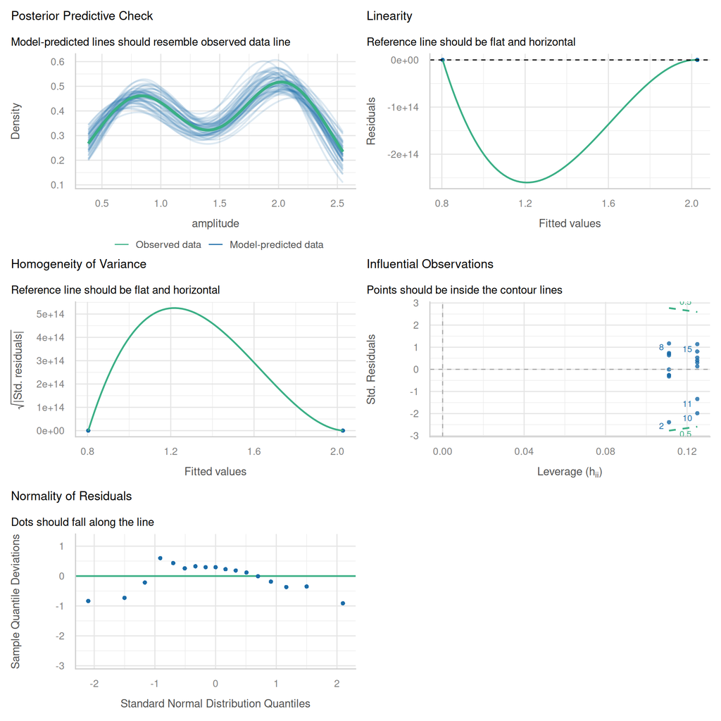

(a) `amplitude ~ ligand`

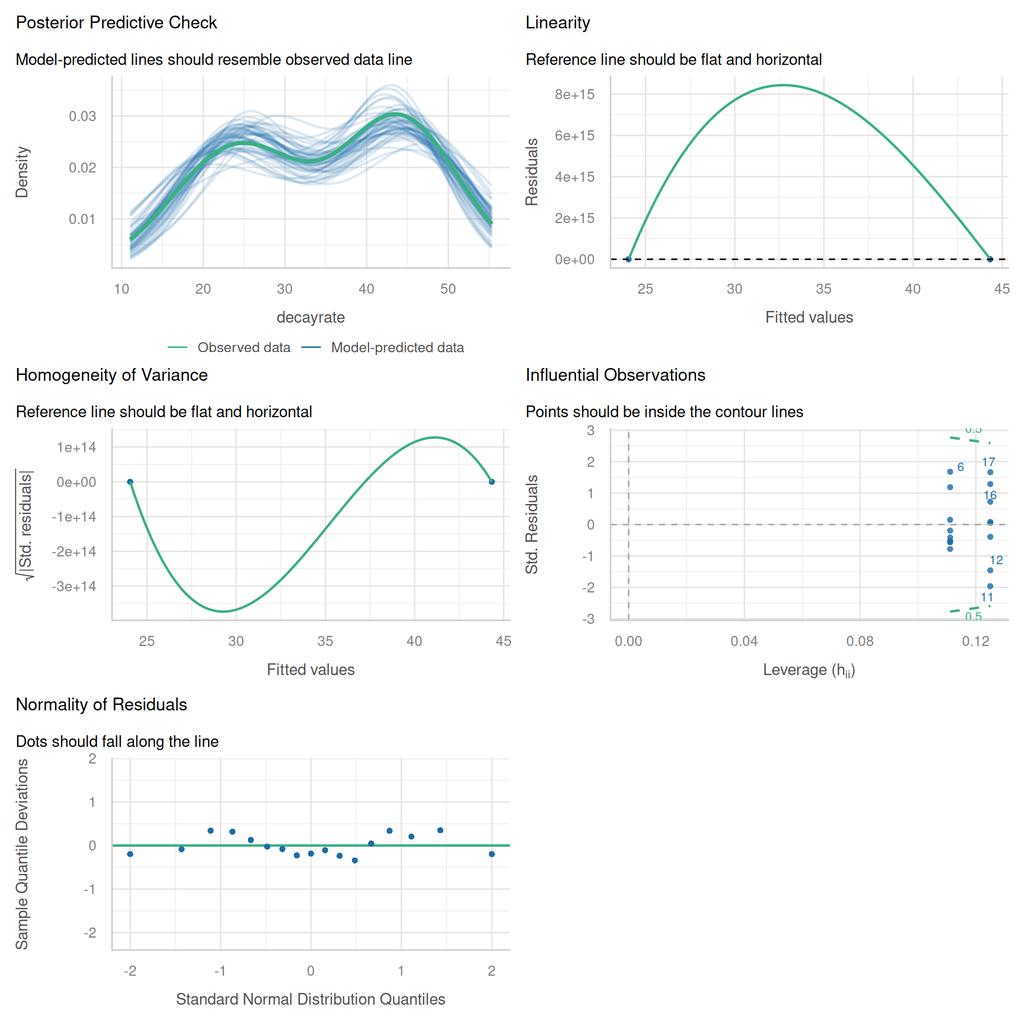

(b) `decayrate ~ ligand`

Figure 1: Diagnostic plots for linear model fits of `amplitude ~ ligand` and `decayrate ~ ligand`. The splines for linearity/heteroscadicity are odd, but the datapoints are not concerning. There is some evidence of non-normality of residuals in the maximum amplitude data, but nothing especially concerning.

```r
# Fit the models
model5a_amp_lm <- lm(amplitude ~ ligand, data=dfms$dfm_5a)
model5a_k_lm <- lm(decayrate ~ ligand, data=dfms$dfm_5a)

# Check model fit
performance::check_model(model5a_amp_lm)
performance::check_model(model5a_k_lm)
```

As the model fit is acceptable, we estimate contrasts in Table 2.

```r
EMM <- emmeans::emmeans(model5a_amp_lm, ~ ligand)
confint(emmeans::contrast(EMM, "pairwise", adjust="sidak")) |>
  kableExtra::kbl(digits=3) |>
  kableExtra::kable_styling(
    bootstrap_options = c("hover", "responsive")
  )
EMM <- emmeans::emmeans(model5a_k_lm, ~ ligand)
confint(emmeans::contrast(EMM, "pairwise", adjust="sidak")) |>
  kableExtra::kbl(digits=3) |>
  kableExtra::kable_styling(
    bootstrap_options = c("hover", "responsive")
  )
```

Table 2: Contrasts for model fits, with Sidak adjustment. No contrast includes zero in the 95% confidence interval estimate.

(a) Maximum amplitude

| contrast | estimate | SE | df | lower.CL | upper.CL |
| --- | --- | --- | --- | --- | --- |
| NH4 - MeA | 1.223 | 0.074 | 15 | 1.066 | 1.38 |

(b) Decay rate

| contrast | estimate | SE | df | lower.CL | upper.CL |
| --- | --- | --- | --- | --- | --- |
| NH4 - MeA | 20.281 | 1.728 | 15 | 16.598 | 23.964 |

As no contrast includes zero in the 95% confidence interval, we conclude that there are differences in amplitude and decay rate constant for each pairwise comparison between ligands.

## The Figures

We plot the differences, indicating P-values for the contrasts in Figure 2.

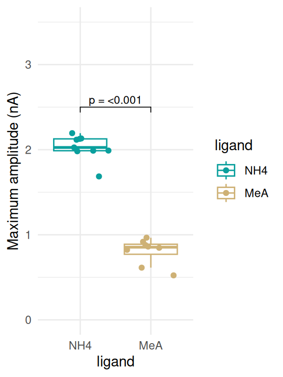

(a) Figure 5a, maximum amplitude

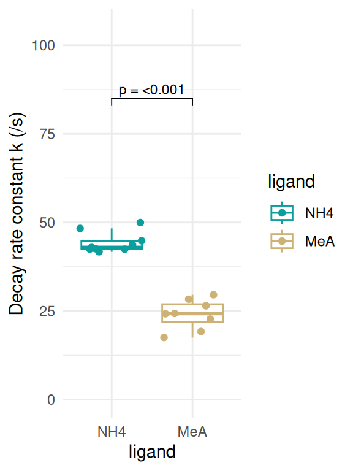

(b) Figure 5a, decay rate

Figure 2: WT measurements across two ligands, replicating figure 5a from the mansucript.

```r
# Get p-values, accounting for heteroscedasticity and multiple testing
# Also generate group1 and group2 columns
EMM_amp <- as.data.frame(pairs(emmeans::emmeans(model5a_amp_lm, ~ ligand),
                               adjust="sidak")) |>
  tidyr::separate(contrast, into=c("group1", "group2"), sep=" - ") |>
  dplyr::mutate(y.position=2.5) |>
  rstatix::add_significance()

EMM_k <- as.data.frame(pairs(emmeans::emmeans(model5a_k_lm, ~ ligand),
                               adjust="sidak")) |>
  tidyr::separate(contrast, into=c("group1", "group2"), sep=" - ") |>
  dplyr::mutate(y.position=85) |>
  rstatix::add_significance()

p5a_amp <- ggplot2::ggplot(dfms$dfm_5a,
                           ggplot2::aes(x=ligand, y=amplitude, color=ligand)) +
  ggplot2::geom_boxplot(outlier.shape = NA) +
  ggplot2::geom_jitter() +
  ggplot2::labs(y="Maximum amplitude (nA)") +
  ggplot2::ylim(0, 3.5) +
  ggplot2::theme_minimal() +
  ggpubr::stat_pvalue_manual(EMM_amp,
                             label="p = {scales::pvalue(p.value)}",
                             size=3, step.increase=0.1)

p5a_k <- ggplot2::ggplot(dfms$dfm_5a,
                         ggplot2::aes(x=ligand, y=decayrate, color=ligand)) +
  ggplot2::geom_boxplot(outlier.shape = NA) +
  ggplot2::geom_jitter() +
  ggplot2::labs(y="Decay rate constant k (/s)") +
  ggplot2::ylim(0, 105) +
  ggplot2::theme_minimal() +
  ggpubr::stat_pvalue_manual(EMM_k,
                             label="p = {scales::pvalue(p.value)}",
                             size=3, step.increase=0.1)

p5a_amp
p5a_k

# Write figures to file (commented out for webpage)
#ggplot2::ggsave("assets/images/fig5a_WT_maximum_amplitude.pdf", p5a_amp)
#ggplot2::ggsave("assets/images/fig5a_WT_maximum_amplitude.png", p5a_amp)
#ggplot2::ggsave("assets/images/fig5a_WT_decay_rate_constant.png", p5a_k)
#ggplot2::ggsave("assets/images/fig5a_WT_decay_rate_constant.pdf", p5a_k)
```

### Downloads

- Download maximum amplitude figure as .pdf
- Download maximum amplitude figure as .png
- Download decay rate constant figure as .pdf
- Download decay rate constant figure as .png